# ggplot

## Manual colors and outside palettes:

The ggplot scale_color_manual() lets you pass any other vector of colors to your ggplot call. This lets you define colors: (WARNING: these can be really bad!)

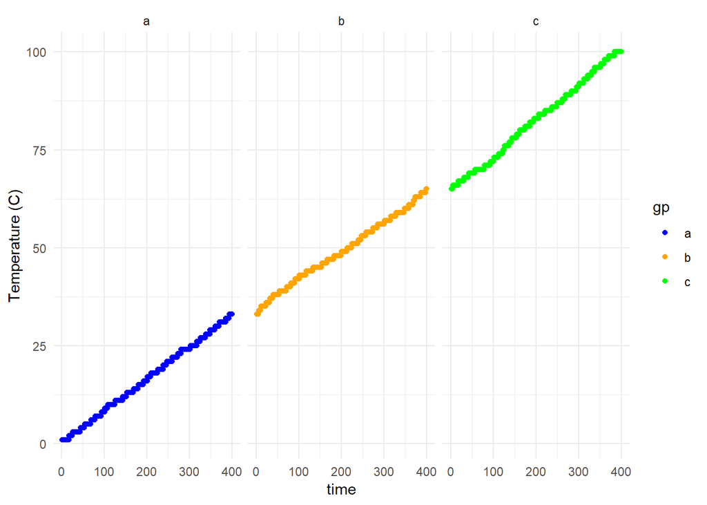

```r
minimal + scale_color_manual(values=c('blue', 'orange', 'green'))
```

Or grab colors from outside libraries: e.g., the wesanderson library:

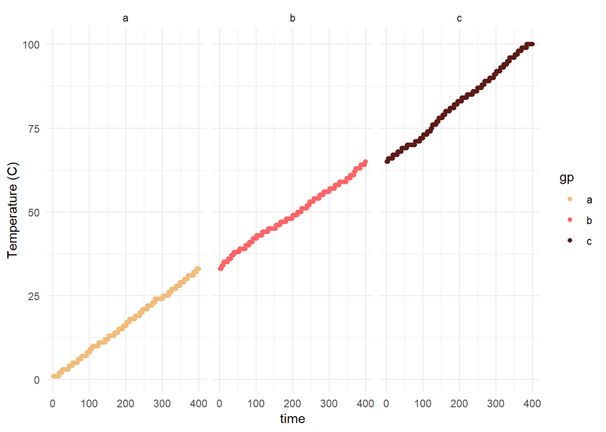

```r
library(wesanderson) #colors from Wes Anderson Movies
minimal + scale_color_manual(values=wes_palette(n=3, name = "GrandBudapest1"))
```

More on colors and coloring functions can be found here:

http://www.sthda.com/english/wiki/ggplot2-colors-how-to-change-colors-automatically-and-manually

# Other plot types:

## Boxplots

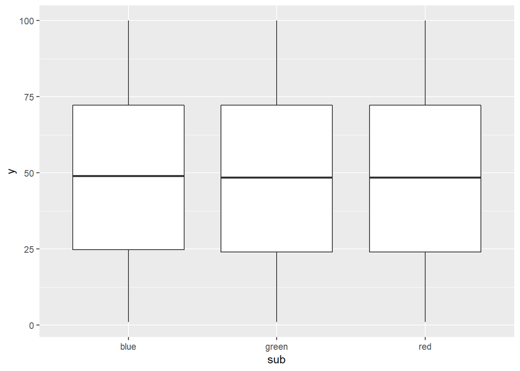

```r
ggplot(data = demo, aes(x = sub, y = y)) +
  geom_boxplot()
```

## Barplots

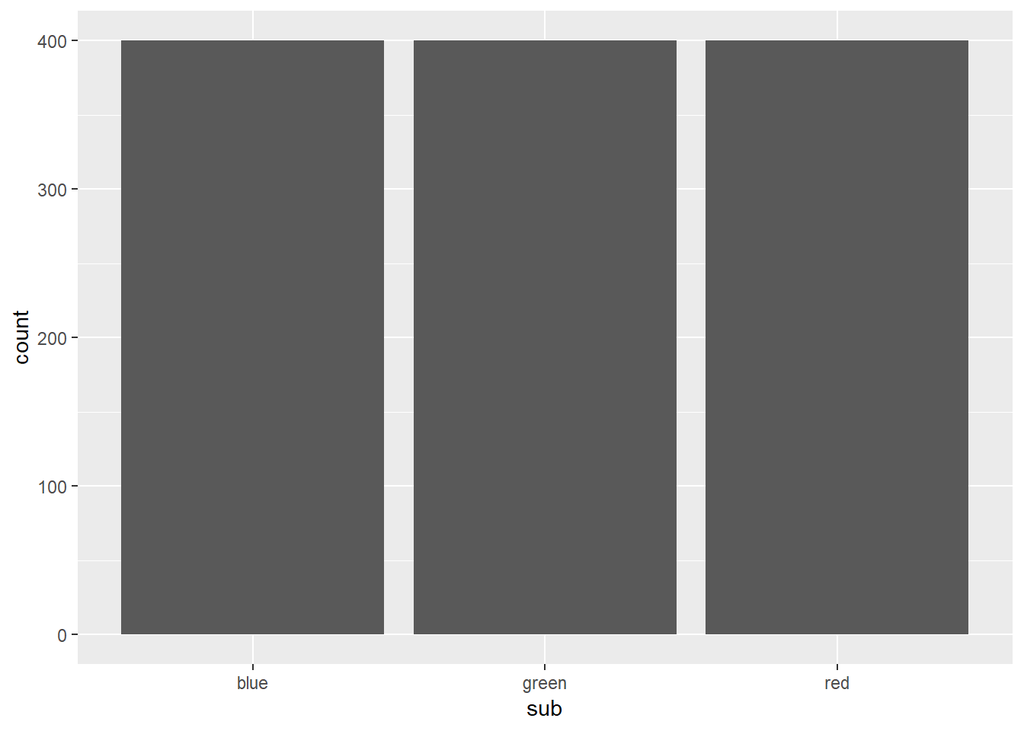

```r
ggplot(data = demo, aes(sub)) +
  geom_bar()
```

## Histograms

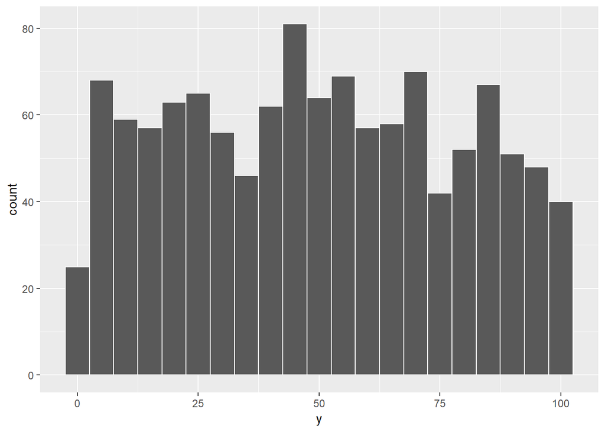

```r
ggplot(data=demo, aes(y)) + geom_histogram(binwidth = 5, col ='white')
```

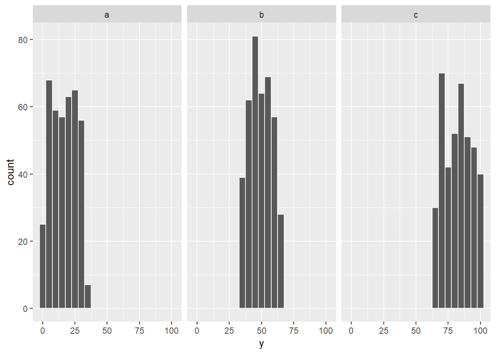

```r
ggplot(data=demo, aes(y)) + geom_histogram(binwidth = 5, col ='white') + facet_wrap(~gp)
```

And many, many, more:

https://r4stats.com/examples/graphics-ggplot2/

# Homework:

Using ggplot (and all of the tips and resources here), make one or more graphic representations of your group’s data and post it to [#ggplot](https://bio200-bioinformatics.slack.com/messages/CCY83KSS2).